Let’s explore some robust regression. After having identified good quality predictors for your our purposes, it makes more sense for us to use an estimation technique that is not easily affected by discrepancies in the data and is reliable even if the data consists of outliers.

### Data and Libraries

Let’s get some data to work with. I am going to use the [quantmod](http://cran.r-project.org/web/packages/quantmod/index.html) package . Let’s just use a simple example.

```r
#install.packages('quantmod')
#install.packages('dynlm')
#install.packages('zoo')
options(warn = -1)
library(quantmod)
library(zoo)

gdp = getSymbols('GDP', src = 'FRED', auto.assign = FALSE)
ind = getSymbols('INDPRO', src = 'FRED', auto.assign = FALSE)

# Convert to timeseries data
gdp = zoo(x = as.numeric(gdp), order.by = as.yearmon(index(gdp)))
ind = zoo(x = as.numeric(ind), order.by = as.yearmon(index(ind)))

# Convert to growth percentages
gdp = log(gdp/lag(gdp,-1))
ind = log(ind/lag(ind,-1))
```

I’ll be using the `dynlm()` function instead of `lm()` since it can handle timeseries data directly.

```r
#install.packages('dynlm')
library(dynlm)

fit = dynlm(gdp ~ ind)
```

Where there is `lm()` there is `summary()`

```r
summary(fit)
```

```
##
## Time series regression with "zoo" data:
## Start = Apr 1947, End = Apr 2014
##
## Call:
## dynlm(formula = gdp ~ ind)
##
## Residuals:
##      Min       1Q   Median       3Q      Max
## -0.03998 -0.00528 -0.00074  0.00473  0.03401
##
## Coefficients:
##             Estimate Std. Error t value Pr(>|t|)
## (Intercept) 0.014651   0.000588    24.9   <2e-16 ***
## ind         0.636451   0.062291    10.2   <2e-16 ***
## ---
## Signif. codes:  0 '***' 0.001 '**' 0.01 '*' 0.05 '.' 0.1 ' ' 1
##
## Residual standard error: 0.00945 on 267 degrees of freedom
## Multiple R-squared:  0.281,  Adjusted R-squared:  0.278
## F-statistic:  104 on 1 and 267 DF,  p-value: <2e-16
```

### Bootstrapping - OLS

Let’s bootstrap the OLS estimate and see what the bootstrapped standard error is.

```r
#Note how dynlm() handles data internally using data frames
mat = data.frame(gdp = as.numeric(fit$model[,1]),
                 ind = as.numeric(fit$model[,2]))
class(mat)
```

```
## [1] "data.frame"
```

I’ll use the `boot()` function to do this. Let’s also create a function which can fit a lm model and return the coefficient on the **Industrial Production Index**.

```r
#install.packeges('boot')
library(boot)

lmFUNC = function(x,indices){
  fit = lm(gdp~ind, data = x[indices,])
  return(coef(fit)[2])
}

lm.boot = boot(data = mat, R = 1000, statistic = lmFUNC)
summary(lm.boot)
```

```
##      R original  bootBias bootSE bootMed
## 1 1000    0.636 -0.000279 0.0727   0.633
```

The coefficient on the industrial production index has a rather high standard error but a much smaller bias value. The bias and standard error can be very easily calculated as shown below. Also, we can plot a histogram and a q-q plot of the bootstrapped estimates using the `plot()` function. Note that **t** here refers to the value of the coefficient on **Industrial Production Index**.

```r
# Bias
(bias = mean(lm.boot$t) - lm.boot$t0)
```

```
##        ind
## -0.0002793
```

```r
# Standard Error
(se = sd(lm.boot$t))
```

```
## [1] 0.07272
```

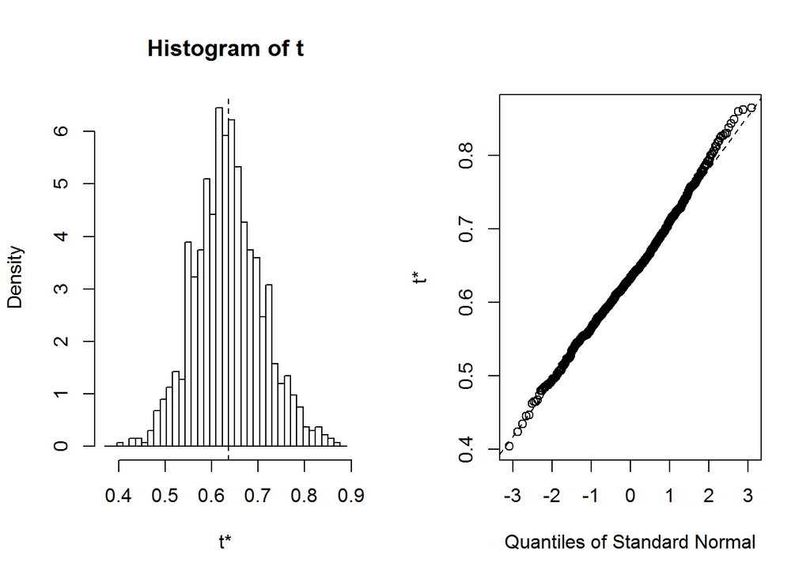

```r
# Plot
plot(lm.boot)
```

### Outlier

It is well known that OLS estimates are sensitive to small changes in data and or outliers. We can show this emperically. Let’s artificially introduce some outliers into our data. Let’s first identify the data point with the highest cook’s distance. Looks like it’s the **14<sup>th</sup>** datapoint in our GDP dataset. Let’s try to distort this specific datapoint.

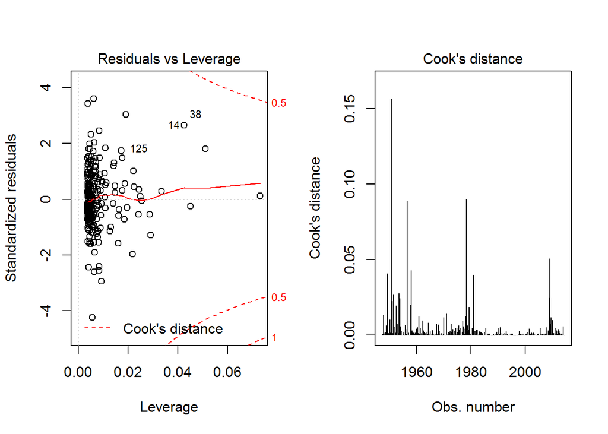

```r
par(mfrow = c(1,2))
plot(fit, which = 5)
plot(fit, which = 4)
```

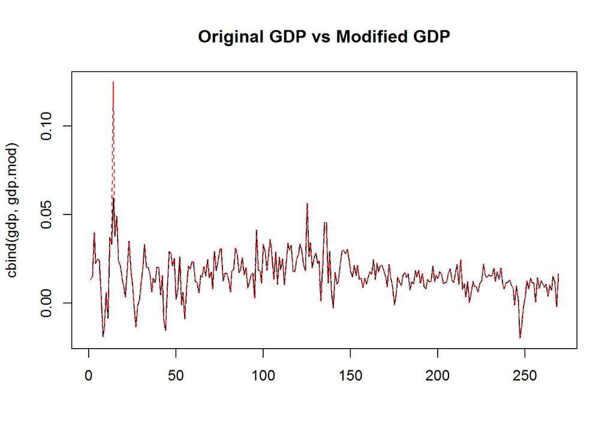

```r
par(mfrow = c(1,1))

gdp.mod = gdp

# Change the 14th datapoint
gdp.mod[14] = gdp[14] + 1.1*gdp[14]
matplot(cbind(gdp,gdp.mod),type = 'l', xlab ="", main = "Original GDP vs Modified GDP")
```

```r
 # Refit
fit.mod = dynlm(gdp.mod ~ ind)
coef(fit.mod)
```

```
## (Intercept)         ind
##     0.01473     0.72137
```

```r
coef(fit)
```

```
## (Intercept)         ind
##     0.01465     0.63645
```

The coefficient on the **Industrial Production Index** has changed by **13.3432** %. We can bootstrap the estimate again to check how the standard error of the bootstrapped estimate changes.

```r
mat = data.frame(gdp = as.numeric(fit.mod$model[,1]),
                 ind = as.numeric(fit.mod$model[,2]))
lm.boot.mod = boot(data = mat, R = 1000, statistic = lmFUNC)
rbind(summary(lm.boot),
      summary(lm.boot.mod))
```

```
##      R original  bootBias bootSE bootMed
## 1 1000    0.636 -0.000279 0.0727   0.633
## 2 1000    0.721  0.000395 0.1333   0.706
```

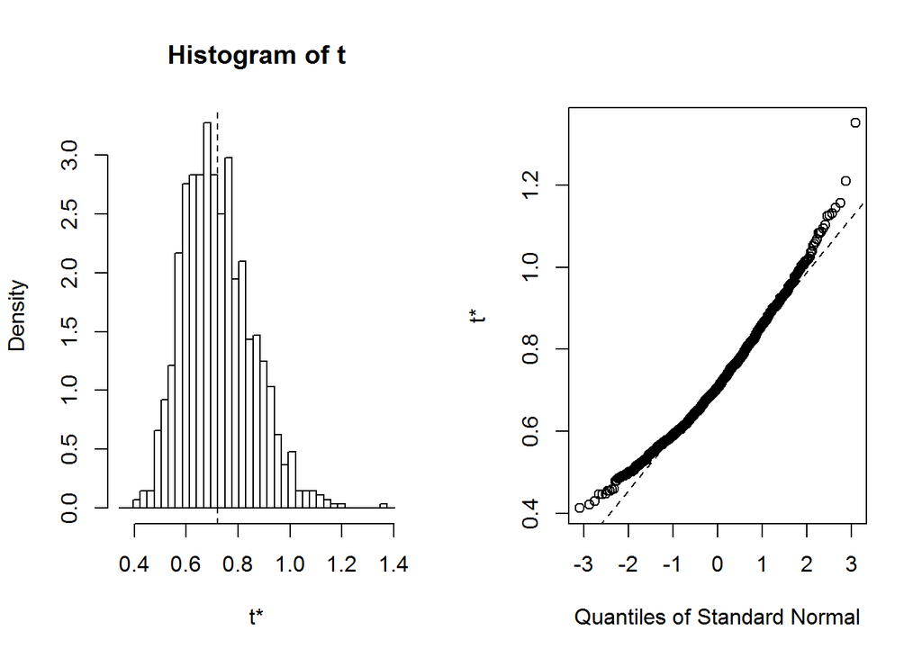

```r
# Plot
plot(lm.boot.mod)
```

Notice that the plots seem to suggest that the bootstrapped estimates are skewed (unlike in the first case). Let’s go trough the same exercise using `lmRob()`

### lmRob()

Let’s first fit the data and see what the coefficients look like and then we can bootstrap the estimates.

```r
#install.packages('robust')
#install.packages('moments')
library(robust)
library(moments)
mat = na.omit(merge(gdp, ind))

#Convert to data frame
mat = data.frame(gdp = as.numeric(mat[,1]),
                 ind = as.numeric(mat[,2]))

fit = lmRob(formula = gdp ~ ind, data = mat)

summary(fit)
```

```
##
## Call:
## lmRob(formula = gdp ~ ind, data = mat)
##
## Residuals:
##       Min        1Q    Median        3Q       Max
## -0.039143 -0.005028 -0.000724  0.005002  0.033295
##
## Coefficients:
##             Estimate Std. Error t value Pr(>|t|)
## (Intercept) 0.014753   0.000545   27.08   <2e-16 ***
## ind         0.525566   0.059160    8.88   <2e-16 ***
## ---
## Signif. codes:  0 '***' 0.001 '**' 0.01 '*' 0.05 '.' 0.1 ' ' 1
##
## Residual standard error: 0.00755 on 267 degrees of freedom
## Multiple R-Squared: 0.187
##
## Test for Bias:
##             statistic  p-value
## M-estimate       10.3 5.68e-03
## LS-estimate      34.1 3.95e-08
```

Note the lower R-Squared value.

```r
lmRobFUNC = function(x,indices){
  fit = lmRob(gdp~ind, data = x[indices,])
  return(coef(fit)[2])
}

lm.boot.rob = boot(data = mat, R = 1000, statistic = lmRobFUNC)
summary(lm.boot.rob)
```

```
##      R original bootBias bootSE bootMed
## 1 1000    0.526   0.0067  0.071   0.534
```

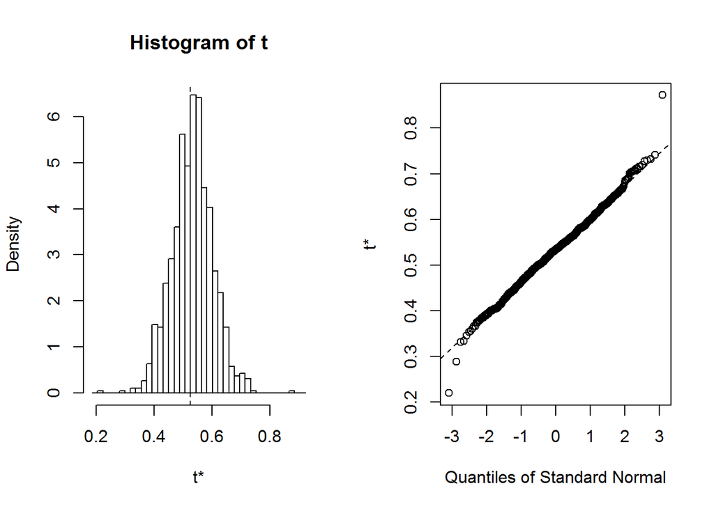

```r
plot(lm.boot.rob)
```

Now let’s introduce the outlier as we did earlier and see what happens.

```r
mat = na.omit(merge(gdp.mod, ind))

#Convert to data frame
mat = data.frame(gdp.mod = as.numeric(mat[,1]),
                 ind = as.numeric(mat[,2]))

fit = lmRob(formula = gdp ~ ind, data = mat)
summary(fit)
```

```
##
## Call:
## lmRob(formula = gdp ~ ind, data = mat)
##
## Residuals:
##       Min        1Q    Median        3Q       Max
## -0.039143 -0.005028 -0.000724  0.005002  0.033295
##
## Coefficients:
##             Estimate Std. Error t value Pr(>|t|)
## (Intercept) 0.014753   0.000545   27.08   <2e-16 ***
## ind         0.525566   0.059160    8.88   <2e-16 ***
## ---
## Signif. codes:  0 '***' 0.001 '**' 0.01 '*' 0.05 '.' 0.1 ' ' 1
##
## Residual standard error: 0.00755 on 267 degrees of freedom
## Multiple R-Squared: 0.187
##
## Test for Bias:
##             statistic  p-value
## M-estimate       10.3 5.68e-03
## LS-estimate      34.1 3.95e-08
```

```r
lm.boot.rob.mod = boot(data = mat, R = 1000, statistic = lmRobFUNC)
summary(lm.boot.rob.mod)
```

```
##      R original bootBias bootSE bootMed
## 1 1000    0.526   -0.523 0.0655 0.00291
```

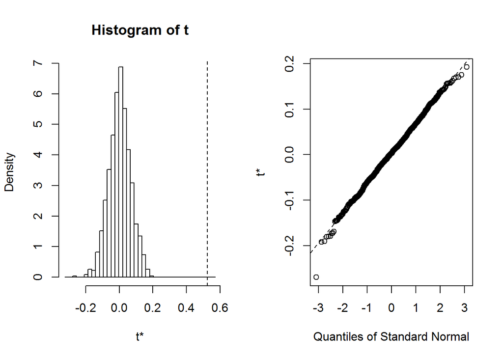

```r
plot(lm.boot.rob.mod)
```

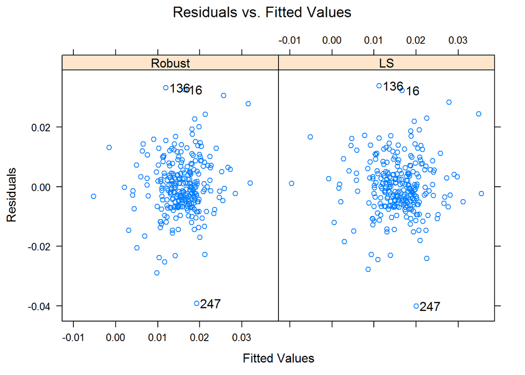

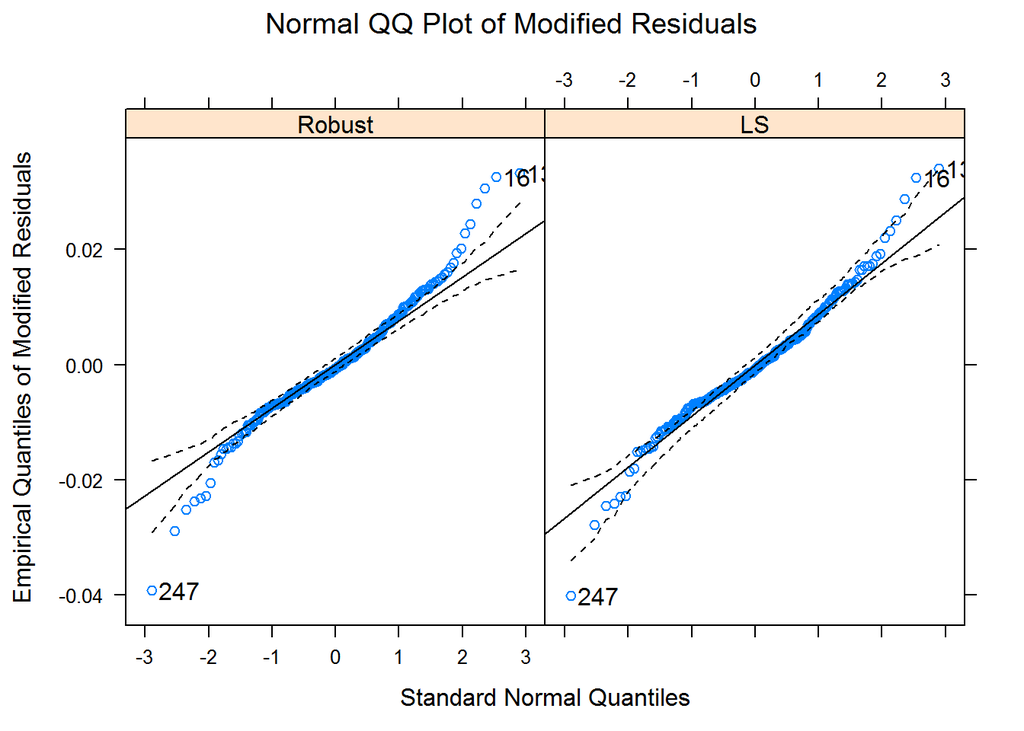

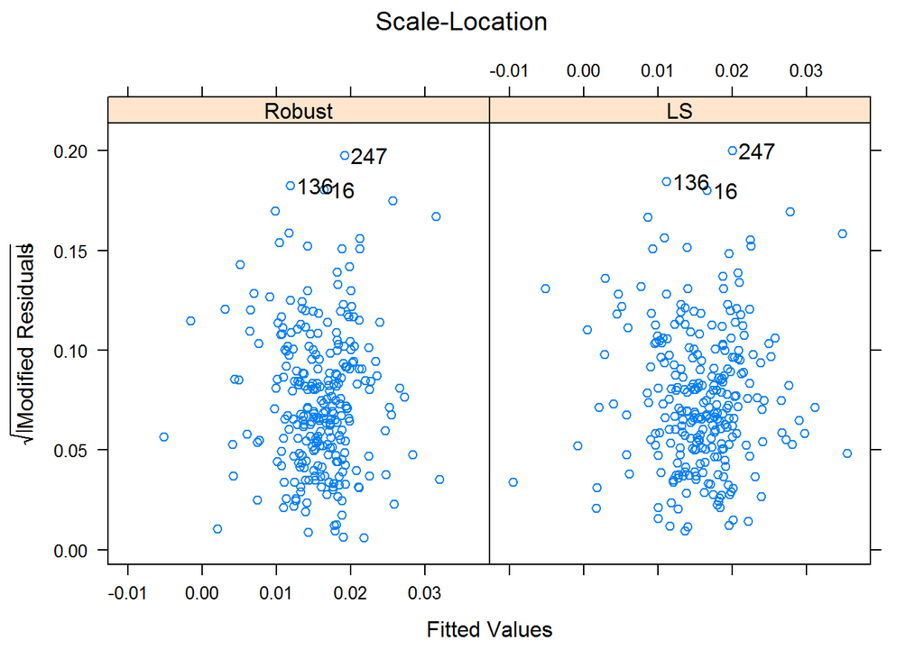

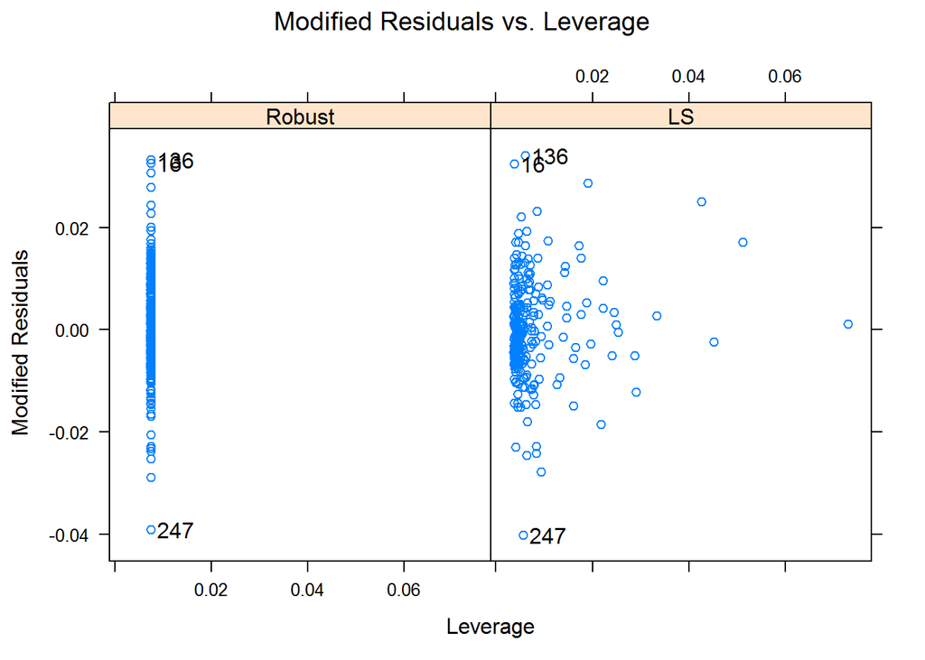

```r
fit.compare = fit.models(list(Robust = "lmRob",
                "LS" = "lm"), formula = gdp ~ ind, data = mat)
par(mfrow = c(2,2))
plot(fit.compare)
```

```r
par(mfrow = c(1,1))
```

Thoughts? Feel free to comment below ! Thanks !